# Risk Factor Analysis

## Outcome Variable

**Outcome Variable:** pers_wasted624

## Predictor Variables

**Intervention Variable:** ever_sstunted06

**Adjustment Set:**

- sex
- arm
- enstunt
- month
- brthmon
- vagbrth
- single
- W_gagebrth
- W_birthwt
- W_birthlen
- W_mage
- W_mhtcm
- W_meducyrs
- W_feducyrs
- W_parity
- delta_month
- delta_brthmon
- delta_vagbrth
- delta_single
- delta_W_gagebrth
- delta_W_birthwt
- delta_W_birthlen
- delta_W_mage
- delta_W_mhtcm
- delta_W_meducyrs
- delta_W_feducyrs
- delta_W_parity

## Stratifying Variables

The analysis was stratified on these variable(s):

- studyid
- country

## Data Summary

| studyid | country | ever_sstunted06 | pers_wasted624 | n_cell | n |
| --- | --- | --- | --- | --- | --- |
| ki0047075b-MAL-ED | BANGLADESH | 0 | 0 | 208 | 239 |
| ki0047075b-MAL-ED | BANGLADESH | 0 | 1 | 16 | 239 |
| ki0047075b-MAL-ED | BANGLADESH | 1 | 0 | 13 | 239 |
| ki0047075b-MAL-ED | BANGLADESH | 1 | 1 | 2 | 239 |
| ki0047075b-MAL-ED | BRAZIL | 0 | 0 | 186 | 202 |
| ki0047075b-MAL-ED | BRAZIL | 0 | 1 | 2 | 202 |
| ki0047075b-MAL-ED | BRAZIL | 1 | 0 | 14 | 202 |
| ki0047075b-MAL-ED | BRAZIL | 1 | 1 | 0 | 202 |
| ki0047075b-MAL-ED | INDIA | 0 | 0 | 193 | 234 |
| ki0047075b-MAL-ED | INDIA | 0 | 1 | 22 | 234 |
| ki0047075b-MAL-ED | INDIA | 1 | 0 | 13 | 234 |
| ki0047075b-MAL-ED | INDIA | 1 | 1 | 6 | 234 |
| ki0047075b-MAL-ED | NEPAL | 0 | 0 | 224 | 234 |
| ki0047075b-MAL-ED | NEPAL | 0 | 1 | 2 | 234 |
| ki0047075b-MAL-ED | NEPAL | 1 | 0 | 8 | 234 |
| ki0047075b-MAL-ED | NEPAL | 1 | 1 | 0 | 234 |
| ki0047075b-MAL-ED | PERU | 0 | 0 | 231 | 264 |
| ki0047075b-MAL-ED | PERU | 0 | 1 | 1 | 264 |
| ki0047075b-MAL-ED | PERU | 1 | 0 | 31 | 264 |
| ki0047075b-MAL-ED | PERU | 1 | 1 | 1 | 264 |
| ki0047075b-MAL-ED | SOUTH AFRICA | 0 | 0 | 231 | 258 |
| ki0047075b-MAL-ED | SOUTH AFRICA | 0 | 1 | 2 | 258 |
| ki0047075b-MAL-ED | SOUTH AFRICA | 1 | 0 | 25 | 258 |
| ki0047075b-MAL-ED | SOUTH AFRICA | 1 | 1 | 0 | 258 |
| ki0047075b-MAL-ED | TANZANIA, UNITED REPUBLIC OF | 0 | 0 | 211 | 244 |
| ki0047075b-MAL-ED | TANZANIA, UNITED REPUBLIC OF | 0 | 1 | 0 | 244 |
| ki0047075b-MAL-ED | TANZANIA, UNITED REPUBLIC OF | 1 | 0 | 33 | 244 |
| ki0047075b-MAL-ED | TANZANIA, UNITED REPUBLIC OF | 1 | 1 | 0 | 244 |
| ki1000108-CMC-V-BCS-2002 | INDIA | 0 | 0 | 260 | 368 |
| ki1000108-CMC-V-BCS-2002 | INDIA | 0 | 1 | 17 | 368 |

[output cut: 118 more lines]

The following strata were considered:

- studyid: ki0047075b-MAL-ED, country: BANGLADESH
- studyid: ki0047075b-MAL-ED, country: BRAZIL
- studyid: ki0047075b-MAL-ED, country: INDIA
- studyid: ki0047075b-MAL-ED, country: NEPAL
- studyid: ki0047075b-MAL-ED, country: PERU
- studyid: ki0047075b-MAL-ED, country: SOUTH AFRICA
- studyid: ki0047075b-MAL-ED, country: TANZANIA, UNITED REPUBLIC OF
- studyid: ki1000108-CMC-V-BCS-2002, country: INDIA
- studyid: ki1000108-IRC, country: INDIA
- studyid: ki1000109-EE, country: PAKISTAN
- studyid: ki1000109-ResPak, country: PAKISTAN
- studyid: ki1000304-VITAMIN-A, country: INDIA
- studyid: ki1000304b-SAS-CompFeed, country: INDIA
- studyid: ki1000304b-SAS-FoodSuppl, country: INDIA
- studyid: ki1017093-NIH-Birth, country: BANGLADESH
- studyid: ki1017093b-PROVIDE, country: BANGLADESH
- studyid: ki1017093c-NIH-Crypto, country: BANGLADESH
- studyid: ki1066203-TanzaniaChild2, country: TANZANIA, UNITED REPUBLIC OF
- studyid: ki1101329-Keneba, country: GAMBIA
- studyid: ki1112895-Burkina Faso Zn, country: BURKINA FASO
- studyid: ki1112895-Guatemala BSC, country: GUATEMALA
- studyid: ki1113344-GMS-Nepal, country: NEPAL
- studyid: ki1114097-CMIN, country: BANGLADESH
- studyid: ki1114097-CMIN, country: BRAZIL
- studyid: ki1114097-CMIN, country: GUINEA-BISSAU
- studyid: ki1114097-CMIN, country: PERU
- studyid: ki1114097-CONTENT, country: PERU
- studyid: ki1119695-PROBIT, country: BELARUS
- studyid: ki1126311-ZVITAMBO, country: ZIMBABWE
- studyid: ki1135781-COHORTS, country: GUATEMALA
- studyid: ki1135781-COHORTS, country: INDIA
- studyid: ki1135781-COHORTS, country: PHILIPPINES
- studyid: ki1148112-iLiNS-DOSE, country: MALAWI
- studyid: ki1148112-iLiNS-DYAD-M, country: MALAWI
- studyid: ki1148112-LCNI-5, country: MALAWI
- studyid: kiGH5241-JiVitA-3, country: BANGLADESH
- studyid: kiGH5241-JiVitA-4, country: BANGLADESH

### Dropped Strata

Some strata were dropped due to rare outcomes:

- studyid: ki0047075b-MAL-ED, country: BANGLADESH
- studyid: ki0047075b-MAL-ED, country: BRAZIL
- studyid: ki0047075b-MAL-ED, country: NEPAL
- studyid: ki0047075b-MAL-ED, country: PERU
- studyid: ki0047075b-MAL-ED, country: SOUTH AFRICA
- studyid: ki0047075b-MAL-ED, country: TANZANIA, UNITED REPUBLIC OF
- studyid: ki1017093b-PROVIDE, country: BANGLADESH
- studyid: ki1112895-Burkina Faso Zn, country: BURKINA FASO
- studyid: ki1112895-Guatemala BSC, country: GUATEMALA
- studyid: ki1114097-CMIN, country: BRAZIL
- studyid: ki1114097-CMIN, country: GUINEA-BISSAU
- studyid: ki1114097-CMIN, country: PERU
- studyid: ki1114097-CONTENT, country: PERU
- studyid: ki1119695-PROBIT, country: BELARUS
- studyid: ki1148112-iLiNS-DYAD-M, country: MALAWI
- studyid: ki1148112-LCNI-5, country: MALAWI

## Methods Detail

We’re interested in the causal parameters $E[Y_a]$ for all values of $a \in \mathcal{A}$. These parameters represent the mean outcome if, possibly contrary to fact, we intervened to set all units to have $A=a$. Under the randomization and positivity assumptions, these are identified by the statistical parameters $\psi_a=E_W[E_{Y|A,W}(Y|A=a,W)]$. In addition, we’re interested in the mean of $Y$, $E[Y]$ under no intervention (the observed mean). We will estimate these parameters by using SuperLearner to fit the relevant likelihood factors – $E_{Y|A,W}(Y|A=a,W)$ and $p(A=a|W)$, and then updating our likelihood fit using a joint TMLE.

For unadjusted analyses ($W=\{\}$), initial likelihoods were estimated using Lrnr_glm to estimate the simple $E(Y|A)$ and Lrnr_mean to estimate $p(A)$. For adjusted analyses, a small library containing Lrnr_glmnet, Lrnr_xgboost, and Lrnr_mean was used.

Having estimated these parameters, we will then use the delta method to estimate relative risks and attributable risks relative to a prespecified baseline level of $A$.

# Results Detail

## Results Plots

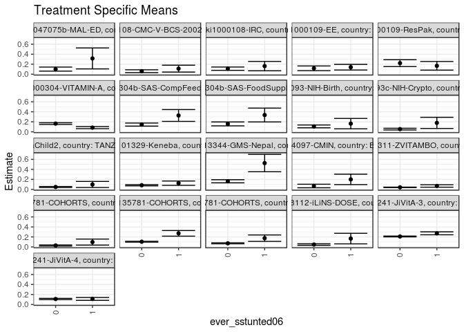

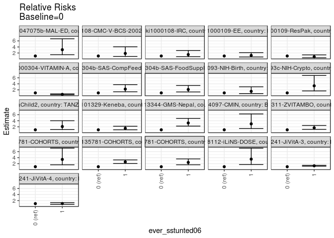

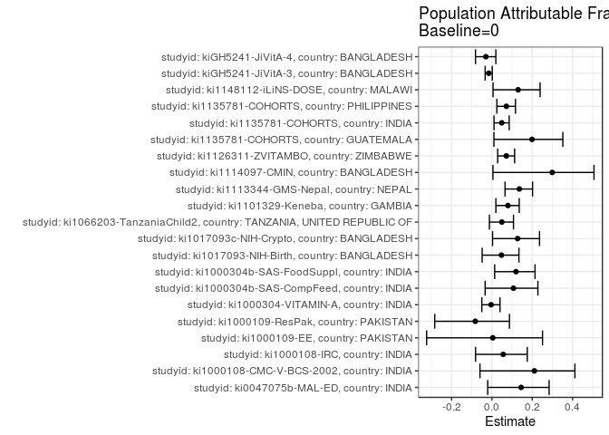

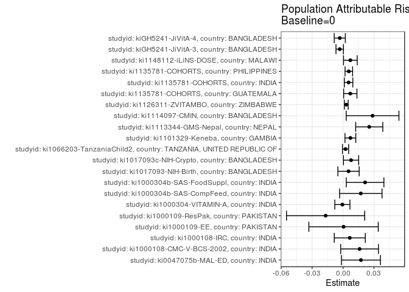

## Results Table

### Parameter: TSM

| studyid | country | intervention_level | baseline_level | estimate | ci_lower | ci_upper |
| --- | --- | --- | --- | --- | --- | --- |
| ki0047075b-MAL-ED | INDIA | 0 | NA | 0.1023256 | 0.0617270 | 0.1429241 |
| ki0047075b-MAL-ED | INDIA | 1 | NA | 0.3157895 | 0.1063324 | 0.5252465 |
| ki1000108-CMC-V-BCS-2002 | INDIA | 0 | NA | 0.0600683 | 0.0316625 | 0.0884740 |
| ki1000108-CMC-V-BCS-2002 | INDIA | 1 | NA | 0.1115938 | 0.0428430 | 0.1803446 |
| ki1000108-IRC | INDIA | 0 | NA | 0.1105474 | 0.0773434 | 0.1437514 |
| ki1000108-IRC | INDIA | 1 | NA | 0.1622008 | 0.0687641 | 0.2556375 |
| ki1000109-EE | PAKISTAN | 0 | NA | 0.1180902 | 0.0711989 | 0.1649814 |
| ki1000109-EE | PAKISTAN | 1 | NA | 0.1403410 | 0.0838332 | 0.1968489 |
| ki1000109-ResPak | PAKISTAN | 0 | NA | 0.2214387 | 0.1530290 | 0.2898484 |
| ki1000109-ResPak | PAKISTAN | 1 | NA | 0.1678858 | 0.0815165 | 0.2542551 |
| ki1000304-VITAMIN-A | INDIA | 0 | NA | 0.1634048 | 0.1461157 | 0.1806939 |
| ki1000304-VITAMIN-A | INDIA | 1 | NA | 0.0831151 | 0.0619179 | 0.1043123 |
| ki1000304b-SAS-CompFeed | INDIA | 0 | NA | 0.1440328 | 0.1133454 | 0.1747203 |
| ki1000304b-SAS-CompFeed | INDIA | 1 | NA | 0.3261987 | 0.2077788 | 0.4446186 |
| ki1000304b-SAS-FoodSuppl | INDIA | 0 | NA | 0.1574013 | 0.1185698 | 0.1962328 |
| ki1000304b-SAS-FoodSuppl | INDIA | 1 | NA | 0.3353697 | 0.1969607 | 0.4737787 |
| ki1017093-NIH-Birth | BANGLADESH | 0 | NA | 0.1075269 | 0.0793430 | 0.1357107 |
| ki1017093-NIH-Birth | BANGLADESH | 1 | NA | 0.1632653 | 0.0596763 | 0.2668543 |
| ki1017093c-NIH-Crypto | BANGLADESH | 0 | NA | 0.0531758 | 0.0362618 | 0.0700898 |
| ki1017093c-NIH-Crypto | BANGLADESH | 1 | NA | 0.1777778 | 0.0659947 | 0.2895609 |
| ki1066203-TanzaniaChild2 | TANZANIA, UNITED REPUBLIC OF | 0 | NA | 0.0470202 | 0.0373165 | 0.0567240 |
| ki1066203-TanzaniaChild2 | TANZANIA, UNITED REPUBLIC OF | 1 | NA | 0.0978261 | 0.0371050 | 0.1585472 |
| ki1101329-Keneba | GAMBIA | 0 | NA | 0.0825219 | 0.0703047 | 0.0947391 |
| ki1101329-Keneba | GAMBIA | 1 | NA | 0.1233401 | 0.0798327 | 0.1668474 |
| ki1113344-GMS-Nepal | NEPAL | 0 | NA | 0.1612526 | 0.1302488 | 0.1922563 |
| ki1113344-GMS-Nepal | NEPAL | 1 | NA | 0.5256013 | 0.3521037 | 0.6990990 |
| ki1114097-CMIN | BANGLADESH | 0 | NA | 0.0670121 | 0.0317396 | 0.1022846 |
| ki1114097-CMIN | BANGLADESH | 1 | NA | 0.1992888 | 0.0947541 | 0.3038236 |
| ki1126311-ZVITAMBO | ZIMBABWE | 0 | NA | 0.0406860 | 0.0362395 | 0.0451326 |
| ki1126311-ZVITAMBO | ZIMBABWE | 1 | NA | 0.0678217 | 0.0434433 | 0.0922002 |
| ki1135781-COHORTS | GUATEMALA | 0 | NA | 0.0283251 | 0.0169080 | 0.0397422 |
| ki1135781-COHORTS | GUATEMALA | 1 | NA | 0.0967742 | 0.0366534 | 0.1568950 |
| ki1135781-COHORTS | INDIA | 0 | NA | 0.1043288 | 0.0957177 | 0.1129399 |
| ki1135781-COHORTS | INDIA | 1 | NA | 0.2714619 | 0.2152669 | 0.3276569 |
| ki1135781-COHORTS | PHILIPPINES | 0 | NA | 0.0723798 | 0.0623719 | 0.0823877 |
| ki1135781-COHORTS | PHILIPPINES | 1 | NA | 0.1751047 | 0.1108547 | 0.2393547 |
| ki1148112-iLiNS-DOSE | MALAWI | 0 | NA | 0.0474308 | 0.0322996 | 0.0625621 |
| ki1148112-iLiNS-DOSE | MALAWI | 1 | NA | 0.1666667 | 0.0611720 | 0.2721613 |
| kiGH5241-JiVitA-3 | BANGLADESH | 0 | NA | 0.2088603 | 0.2008731 | 0.2168476 |
| kiGH5241-JiVitA-3 | BANGLADESH | 1 | NA | 0.2721657 | 0.2427635 | 0.3015678 |
| kiGH5241-JiVitA-4 | BANGLADESH | 0 | NA | 0.1097148 | 0.0974914 | 0.1219382 |
| kiGH5241-JiVitA-4 | BANGLADESH | 1 | NA | 0.1114522 | 0.0830575 | 0.1398469 |

### Parameter: E(Y)

| studyid | country | intervention_level | baseline_level | estimate | ci_lower | ci_upper |
| --- | --- | --- | --- | --- | --- | --- |
| ki0047075b-MAL-ED | INDIA | NA | NA | 0.1196581 | 0.0779840 | 0.1613323 |
| ki1000108-CMC-V-BCS-2002 | INDIA | NA | NA | 0.0760870 | 0.0489610 | 0.1032130 |
| ki1000108-IRC | INDIA | NA | NA | 0.1170732 | 0.0859146 | 0.1482317 |
| ki1000109-EE | PAKISTAN | NA | NA | 0.1185984 | 0.0856546 | 0.1515422 |
| ki1000109-ResPak | PAKISTAN | NA | NA | 0.2045455 | 0.1511224 | 0.2579685 |
| ki1000304-VITAMIN-A | INDIA | NA | NA | 0.1627604 | 0.1476839 | 0.1778369 |
| ki1000304b-SAS-CompFeed | INDIA | NA | NA | 0.1612426 | 0.1416314 | 0.1808538 |
| ki1000304b-SAS-FoodSuppl | INDIA | NA | NA | 0.1787565 | 0.1404842 | 0.2170288 |
| ki1017093-NIH-Birth | BANGLADESH | NA | NA | 0.1128405 | 0.0854611 | 0.1402198 |
| ki1017093c-NIH-Crypto | BANGLADESH | NA | NA | 0.0609418 | 0.0434802 | 0.0784034 |
| ki1066203-TanzaniaChild2 | TANZANIA, UNITED REPUBLIC OF | NA | NA | 0.0494534 | 0.0397554 | 0.0591514 |
| ki1101329-Keneba | GAMBIA | NA | NA | 0.0896333 | 0.0777184 | 0.1015482 |
| ki1113344-GMS-Nepal | NEPAL | NA | NA | 0.1866438 | 0.1550166 | 0.2182711 |
| ki1114097-CMIN | BANGLADESH | NA | NA | 0.0956175 | 0.0591654 | 0.1320697 |
| ki1126311-ZVITAMBO | ZIMBABWE | NA | NA | 0.0438186 | 0.0394817 | 0.0481556 |
| ki1135781-COHORTS | GUATEMALA | NA | NA | 0.0353591 | 0.0233199 | 0.0473983 |
| ki1135781-COHORTS | INDIA | NA | NA | 0.1096840 | 0.1017209 | 0.1176470 |
| ki1135781-COHORTS | PHILIPPINES | NA | NA | 0.0779833 | 0.0679723 | 0.0879943 |
| ki1148112-iLiNS-DOSE | MALAWI | NA | NA | 0.0545229 | 0.0388484 | 0.0701975 |
| kiGH5241-JiVitA-3 | BANGLADESH | NA | NA | 0.2056324 | 0.1980748 | 0.2131900 |
| kiGH5241-JiVitA-4 | BANGLADESH | NA | NA | 0.1065428 | 0.0957758 | 0.1173098 |

### Parameter: RR

| studyid | country | intervention_level | baseline_level | estimate | ci_lower | ci_upper |
| --- | --- | --- | --- | --- | --- | --- |
| ki0047075b-MAL-ED | INDIA | 0 | 0 | 1.0000000 | 1.0000000 | 1.0000000 |
| ki0047075b-MAL-ED | INDIA | 1 | 0 | 3.0861244 | 1.4247928 | 6.6845956 |
| ki1000108-CMC-V-BCS-2002 | INDIA | 0 | 0 | 1.0000000 | 1.0000000 | 1.0000000 |
| ki1000108-CMC-V-BCS-2002 | INDIA | 1 | 0 | 1.8577825 | 0.8533717 | 4.0443755 |
| ki1000108-IRC | INDIA | 0 | 0 | 1.0000000 | 1.0000000 | 1.0000000 |
| ki1000108-IRC | INDIA | 1 | 0 | 1.4672517 | 0.7655726 | 2.8120486 |
| ki1000109-EE | PAKISTAN | 0 | 0 | 1.0000000 | 1.0000000 | 1.0000000 |
| ki1000109-EE | PAKISTAN | 1 | 0 | 1.1884227 | 0.6729825 | 2.0986407 |
| ki1000109-ResPak | PAKISTAN | 0 | 0 | 1.0000000 | 1.0000000 | 1.0000000 |
| ki1000109-ResPak | PAKISTAN | 1 | 0 | 0.7581594 | 0.4159746 | 1.3818290 |
| ki1000304-VITAMIN-A | INDIA | 0 | 0 | 1.0000000 | 1.0000000 | 1.0000000 |
| ki1000304-VITAMIN-A | INDIA | 1 | 0 | 0.5086453 | 0.3867665 | 0.6689308 |
| ki1000304b-SAS-CompFeed | INDIA | 0 | 0 | 1.0000000 | 1.0000000 | 1.0000000 |
| ki1000304b-SAS-CompFeed | INDIA | 1 | 0 | 2.2647525 | 1.3724255 | 3.7372548 |
| ki1000304b-SAS-FoodSuppl | INDIA | 0 | 0 | 1.0000000 | 1.0000000 | 1.0000000 |
| ki1000304b-SAS-FoodSuppl | INDIA | 1 | 0 | 2.1306667 | 1.3165219 | 3.4482833 |
| ki1017093-NIH-Birth | BANGLADESH | 0 | 0 | 1.0000000 | 1.0000000 | 1.0000000 |
| ki1017093-NIH-Birth | BANGLADESH | 1 | 0 | 1.5183673 | 0.7642537 | 3.0165892 |
| ki1017093c-NIH-Crypto | BANGLADESH | 0 | 0 | 1.0000000 | 1.0000000 | 1.0000000 |
| ki1017093c-NIH-Crypto | BANGLADESH | 1 | 0 | 3.3432099 | 1.6524803 | 6.7638036 |
| ki1066203-TanzaniaChild2 | TANZANIA, UNITED REPUBLIC OF | 0 | 0 | 1.0000000 | 1.0000000 | 1.0000000 |
| ki1066203-TanzaniaChild2 | TANZANIA, UNITED REPUBLIC OF | 1 | 0 | 2.0805106 | 1.0816633 | 4.0017298 |
| ki1101329-Keneba | GAMBIA | 0 | 0 | 1.0000000 | 1.0000000 | 1.0000000 |
| ki1101329-Keneba | GAMBIA | 1 | 0 | 1.4946345 | 1.0197773 | 2.1906081 |
| ki1113344-GMS-Nepal | NEPAL | 0 | 0 | 1.0000000 | 1.0000000 | 1.0000000 |
| ki1113344-GMS-Nepal | NEPAL | 1 | 0 | 3.2594915 | 2.2265094 | 4.7717225 |
| ki1114097-CMIN | BANGLADESH | 0 | 0 | 1.0000000 | 1.0000000 | 1.0000000 |
| ki1114097-CMIN | BANGLADESH | 1 | 0 | 2.9739248 | 1.4124004 | 6.2618422 |
| ki1126311-ZVITAMBO | ZIMBABWE | 0 | 0 | 1.0000000 | 1.0000000 | 1.0000000 |
| ki1126311-ZVITAMBO | ZIMBABWE | 1 | 0 | 1.6669536 | 1.1449543 | 2.4269391 |
| ki1135781-COHORTS | GUATEMALA | 0 | 0 | 1.0000000 | 1.0000000 | 1.0000000 |
| ki1135781-COHORTS | GUATEMALA | 1 | 0 | 3.4165498 | 1.6291833 | 7.1648246 |
| ki1135781-COHORTS | INDIA | 0 | 0 | 1.0000000 | 1.0000000 | 1.0000000 |
| ki1135781-COHORTS | INDIA | 1 | 0 | 2.6019845 | 2.0826297 | 3.2508532 |
| ki1135781-COHORTS | PHILIPPINES | 0 | 0 | 1.0000000 | 1.0000000 | 1.0000000 |
| ki1135781-COHORTS | PHILIPPINES | 1 | 0 | 2.4192489 | 1.6344404 | 3.5808986 |
| ki1148112-iLiNS-DOSE | MALAWI | 0 | 0 | 1.0000000 | 1.0000000 | 1.0000000 |
| ki1148112-iLiNS-DOSE | MALAWI | 1 | 0 | 3.5138888 | 1.7296293 | 7.1387639 |
| kiGH5241-JiVitA-3 | BANGLADESH | 0 | 0 | 1.0000000 | 1.0000000 | 1.0000000 |
| kiGH5241-JiVitA-3 | BANGLADESH | 1 | 0 | 1.3030989 | 1.1620570 | 1.4612594 |
| kiGH5241-JiVitA-4 | BANGLADESH | 0 | 0 | 1.0000000 | 1.0000000 | 1.0000000 |
| kiGH5241-JiVitA-4 | BANGLADESH | 1 | 0 | 1.0158356 | 0.7683326 | 1.3430668 |

### Parameter: PAR

| studyid | country | intervention_level | baseline_level | estimate | ci_lower | ci_upper |
| --- | --- | --- | --- | --- | --- | --- |
| ki0047075b-MAL-ED | INDIA | 0 | NA | 0.0173325 | -0.0015396 | 0.0362047 |
| ki1000108-CMC-V-BCS-2002 | INDIA | 0 | NA | 0.0160187 | -0.0022780 | 0.0343154 |
| ki1000108-IRC | INDIA | 0 | NA | 0.0065258 | -0.0085108 | 0.0215624 |
| ki1000109-EE | PAKISTAN | 0 | NA | 0.0005082 | -0.0331200 | 0.0341364 |
| ki1000109-ResPak | PAKISTAN | 0 | NA | -0.0168932 | -0.0547789 | 0.0209924 |
| ki1000304-VITAMIN-A | INDIA | 0 | NA | -0.0006444 | -0.0079865 | 0.0066977 |
| ki1000304b-SAS-CompFeed | INDIA | 0 | NA | 0.0172098 | -0.0033605 | 0.0377800 |
| ki1000304b-SAS-FoodSuppl | INDIA | 0 | NA | 0.0213552 | 0.0031201 | 0.0395902 |
| ki1017093-NIH-Birth | BANGLADESH | 0 | NA | 0.0053136 | -0.0050182 | 0.0156453 |
| ki1017093c-NIH-Crypto | BANGLADESH | 0 | NA | 0.0077661 | 0.0003846 | 0.0151475 |
| ki1066203-TanzaniaChild2 | TANZANIA, UNITED REPUBLIC OF | 0 | NA | 0.0024332 | -0.0005515 | 0.0054178 |
| ki1101329-Keneba | GAMBIA | 0 | NA | 0.0071114 | 0.0018596 | 0.0123633 |
| ki1113344-GMS-Nepal | NEPAL | 0 | NA | 0.0253913 | 0.0122591 | 0.0385235 |
| ki1114097-CMIN | BANGLADESH | 0 | NA | 0.0286055 | 0.0030497 | 0.0541613 |
| ki1126311-ZVITAMBO | ZIMBABWE | 0 | NA | 0.0031326 | 0.0012678 | 0.0049974 |
| ki1135781-COHORTS | GUATEMALA | 0 | NA | 0.0070340 | 0.0006011 | 0.0134669 |
| ki1135781-COHORTS | INDIA | 0 | NA | 0.0053552 | 0.0012176 | 0.0094927 |
| ki1135781-COHORTS | PHILIPPINES | 0 | NA | 0.0056035 | 0.0019508 | 0.0092562 |
| ki1148112-iLiNS-DOSE | MALAWI | 0 | NA | 0.0070921 | 0.0004608 | 0.0137233 |
| kiGH5241-JiVitA-3 | BANGLADESH | 0 | NA | -0.0032279 | -0.0068440 | 0.0003882 |
| kiGH5241-JiVitA-4 | BANGLADESH | 0 | NA | -0.0031720 | -0.0085529 | 0.0022089 |

### Parameter: PAF

| studyid | country | intervention_level | baseline_level | estimate | ci_lower | ci_upper |
| --- | --- | --- | --- | --- | --- | --- |
| ki0047075b-MAL-ED | INDIA | 0 | NA | 0.1448505 | -0.0207766 | 0.2836036 |
| ki1000108-CMC-V-BCS-2002 | INDIA | 0 | NA | 0.2105313 | -0.0592903 | 0.4116242 |
| ki1000108-IRC | INDIA | 0 | NA | 0.0557412 | -0.0811083 | 0.1752680 |
| ki1000109-EE | PAKISTAN | 0 | NA | 0.0042853 | -0.3237463 | 0.2510288 |
| ki1000109-ResPak | PAKISTAN | 0 | NA | -0.0825891 | -0.2836152 | 0.0869544 |
| ki1000304-VITAMIN-A | INDIA | 0 | NA | -0.0039593 | -0.0500687 | 0.0401254 |
| ki1000304b-SAS-CompFeed | INDIA | 0 | NA | 0.1067321 | -0.0336189 | 0.2280254 |
| ki1000304b-SAS-FoodSuppl | INDIA | 0 | NA | 0.1194652 | 0.0136867 | 0.2138994 |
| ki1017093-NIH-Birth | BANGLADESH | 0 | NA | 0.0470894 | -0.0484184 | 0.1338966 |
| ki1017093c-NIH-Crypto | BANGLADESH | 0 | NA | 0.1274339 | 0.0032097 | 0.2361767 |
| ki1066203-TanzaniaChild2 | TANZANIA, UNITED REPUBLIC OF | 0 | NA | 0.0492015 | -0.0123635 | 0.1070224 |
| ki1101329-Keneba | GAMBIA | 0 | NA | 0.0793392 | 0.0196575 | 0.1353877 |
| ki1113344-GMS-Nepal | NEPAL | 0 | NA | 0.1360414 | 0.0650400 | 0.2016509 |
| ki1114097-CMIN | BANGLADESH | 0 | NA | 0.2991655 | 0.0050810 | 0.5063227 |
| ki1126311-ZVITAMBO | ZIMBABWE | 0 | NA | 0.0714904 | 0.0284816 | 0.1125953 |
| ki1135781-COHORTS | GUATEMALA | 0 | NA | 0.1989301 | 0.0099812 | 0.3518174 |
| ki1135781-COHORTS | INDIA | 0 | NA | 0.0488236 | 0.0105273 | 0.0856378 |
| ki1135781-COHORTS | PHILIPPINES | 0 | NA | 0.0718555 | 0.0246435 | 0.1167821 |
| ki1148112-iLiNS-DOSE | MALAWI | 0 | NA | 0.1300755 | 0.0056017 | 0.2389682 |
| kiGH5241-JiVitA-3 | BANGLADESH | 0 | NA | -0.0156975 | -0.0335141 | 0.0018120 |
| kiGH5241-JiVitA-4 | BANGLADESH | 0 | NA | -0.0297722 | -0.0815059 | 0.0194869 |